# KUidas tuvastada pettust?

Risto Hinno

Tuesday, May 26, 2015

## Sissejuhatus

Markus “Märul” Veekahuri isa on politseinik, ema on politseinik, mõlemad vanaemad on politseinikud ja õde on politseinik. Algul vaadati viltuselt Markuse soovile ülikooli statistikat õppima minna, kuid pärast kahte kuud vaikimist vahetati telefoni teel esimene “tere” ning lepiti uuesti ära.

Kuid nagu elus ikka, ei kuku käbi kännust kaugele. Markus läks tööle Politsei- ja Piirivalveametisse ning tema igapäevatööks sai pettuste tuvastamine, kasutades statistilisi meetodeid. Tema ametirelvaks on Benfordi seadus.

Benfordi seadus (sageli nimetatud kui esimese numbri seadus) kirjeldab arvu esimese numbri sagedust. Paljudes reaalsetes andmetes esineb number 1 esinumbrina umbes 30% juhtudest ning iga järgneva numbri sagedus kahaneb monotoonselt.

## Maksude andmestik

Loe sisse Maksu- ja Tolliameti maksude andmestik ja tutvu andmetega. Andmestikus on järgnevad tunnused:

- registrikood: juriidilise isiku registrikood
- nimi: juriidilise isiku nimi
- liik: kas tegemist on äriühingu, MTÜ, FIE vms
- kaibemaksukohustlane: kas juriidiline isik on käibemaksukohustlane
- maakond: millises maakonnas on juriidiline isik registreeritud
- riiklikud_maksud: käibemaks, tollimaks jne
- toojoumaksud_ja_maksed: sotsiaalmaks, töötuskindlustusmakse jne

## Ülesanne 1 (2 punkti)

Tee 3 joonist, mis iseloomustavad hästi seda andmestikku.

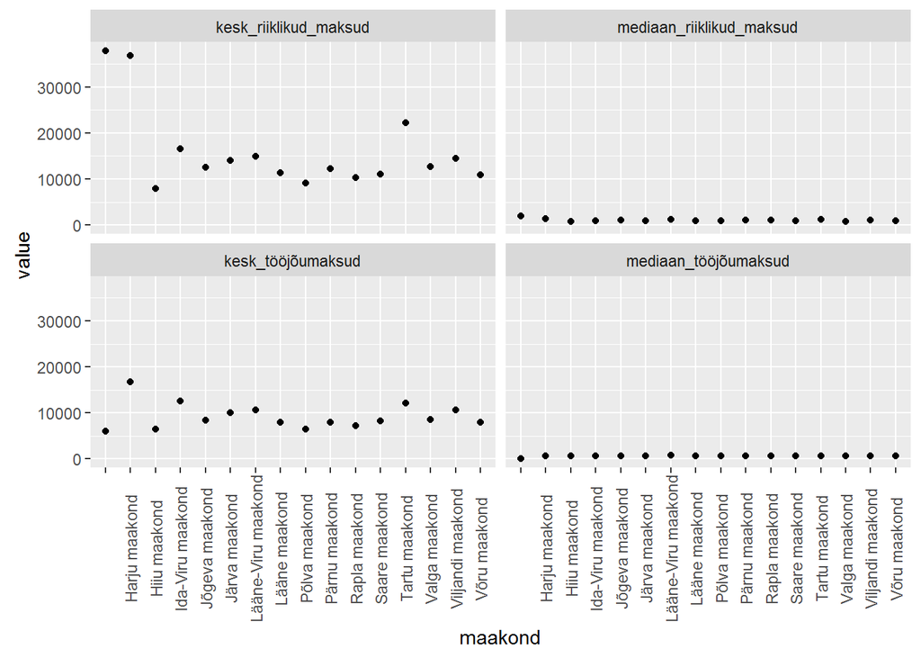

```r
maksud=read.csv2("./data/tolliamet_maksud.csv")
maksud$riiklikud_maksud=as.numeric(as.character(maksud$riiklikud_maksud))
maksud$toojoumaksud_ja_maksed=as.numeric(as.character(
    maksud$toojoumaksud_ja_maksed))

library(ggplot2)
#maakonna keskmised
library(dplyr)
library(reshape2)
maksud_maakond_group=maksud %>%
    group_by(maakond)%>%
summarise(kesk_riiklikud_maksud= mean(riiklikud_maksud, na.rm=T),
          mediaan_riiklikud_maksud=median(riiklikud_maksud, na.rm=T),
          kesk_tööjõumaksud= mean(toojoumaksud_ja_maksed, na.rm=T),
          mediaan_tööjõumaksud=median(toojoumaksud_ja_maksed, na.rm=T))%>%
    melt(id.vars="maakond")

ggplot(maksud_maakond_group, aes(x=maakond, y=value))+
    geom_point()+
    facet_wrap(~variable)+
    theme(axis.text.x  = element_text(angle=90, vjust=0.5))
```

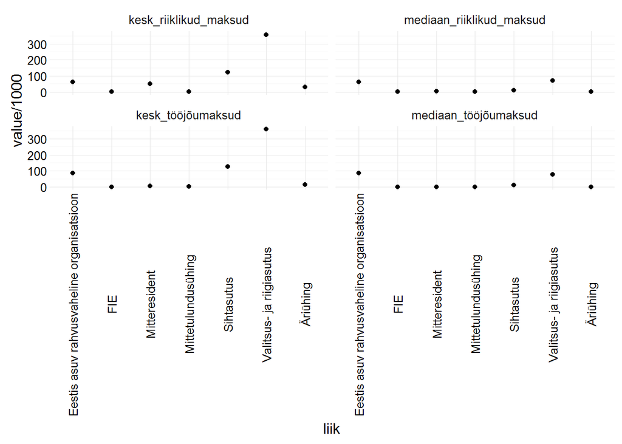

```r
#jur vormi keskmised
maksud_liik_group=maksud %>%
    group_by(liik)%>%
    summarise(kesk_riiklikud_maksud= mean(riiklikud_maksud, na.rm=T),
              mediaan_riiklikud_maksud=median(riiklikud_maksud, na.rm=T),
              kesk_tööjõumaksud= mean(toojoumaksud_ja_maksed, na.rm=T),
              mediaan_tööjõumaksud=median(toojoumaksud_ja_maksed, na.rm=T))%>%
    melt(id.vars="liik")

ggplot(maksud_liik_group, aes(x=liik, y=value/1000))+
    geom_point()+
    facet_wrap(~variable)+
    theme_minimal()+
    theme(axis.text.x  = element_text(angle=90, vjust=0.5))
```

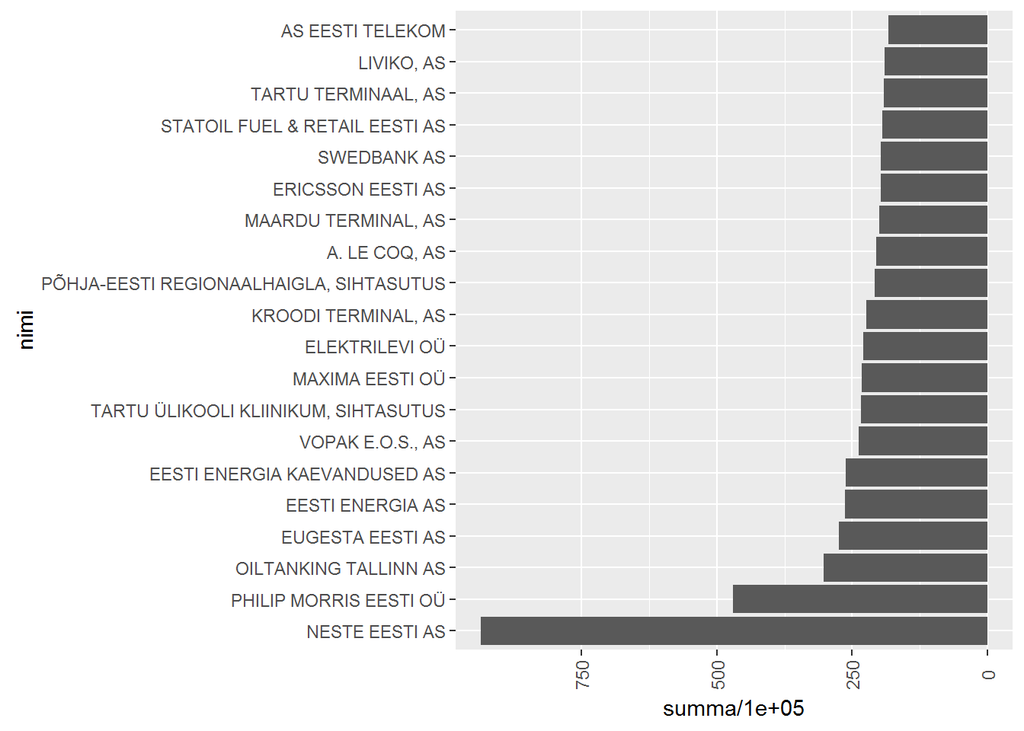

```r
maksud_sort=maksud%>%
    mutate(summa=riiklikud_maksud+toojoumaksud_ja_maksed)%>%
    arrange(-summa)
#see on selleks, et ggplot kuvaks maksude järjekorras, mitte tähestikulises
#järjekorras
maksud_sort$nimi <- as.character(maksud_sort$nimi)
#Then turn it back into an ordered factor
maksud_sort$nimi <- factor(maksud_sort$nimi, levels=unique(maksud_sort$nimi))

ggplot(subset(maksud_sort, liik!="Valitsus- ja riigiasutus")[1:20,],
       aes(x=nimi, y=summa/100000))+
    geom_bar(stat="identity")+
    scale_y_reverse()+
    theme(axis.text.x  = element_text(angle=90, vjust=0.5))+
    coord_flip()
```